# MySection

## Sentiment Analysis by Sentence

In this section, we explore the role of sentiments in the stock market, specifically the stock of Tesla. Using vaderSentiment's SentimentIntensityAnalyzer, determine the polarity, or strength, of the opinion the article has. After text sentiments are acquired, we use the stock's history as data to determine if any relationship can be found. Lastly, the polarity score and stock information is displayed on the same graph. To experiment with stock information, we first use the change in stock prices, then use the actual stock price, and determine which helps us visualize the relationship better.

Data trimming was performed on our dataset of articles because as the date grew older, there was less and less articles per day, sometimes even just one article. It was decided that these articles would have too much bias and power in affecting the sentiment score, and were removed. The final dataset composed of articles from approximately a year back, starting in October 2018. Also, the dates consisted of Year, Month, Day, Hour and Minutes. Hour and Minutes were removed from dates because they were unnecessary.

An issue that we encountered was that sometimes, the sentiment scores reported 0, which meant that they were neutral. We believed that these articles, although informative, had elements of text that were not successfully interpreted by the vaderSentiment library. To remedy this, those datapoints were given small random scores towards their orignal label of either 'positive', 'negative', or 'neutral'.

For days that had many articles, the average sentiment score was calculated and taken into consideration.

```python
import seaborn as sns
import matplotlib.pyplot as plt
from nltk.sentiment.vader import SentimentIntensityAnalyzer as SIA
from vaderSentiment.vaderSentiment import SentimentIntensityAnalyzer
from datetime import timedelta
from sklearn.model_selection import train_test_split
from sklearn.feature_extraction.text import TfidfVectorizer
from sklearn.svm import SVR
from keras.preprocessing.text import Tokenizer
import io, time, json, re, random, requests
import pandas as pd
from bs4 import BeautifulSoup
import pandas_datareader as pdr
import datetime
import numpy as np
```

```python
def getData(path):
    #Path is a text file
    total = pd.read_csv(path)
    total["date"] = pd.to_datetime(total["date"])
    total["date"] = pd.to_datetime(total['date'].apply(lambda x: x.strftime('%Y-%m-%d')))
    total["sentiment"] = total["sentiment"].replace(to_replace=['Positive', 'Negative','Neutral'], value=['pos', 'neg','neu'])
    total = total.loc[total['date'] >= pd.to_datetime("2018-10-1")]
    return total

def analyzeSentiment(data):
    #text is type(str)
    analyzer = SentimentIntensityAnalyzer()
    score = analyzer.polarity_scores(data['text'])
    if(score[data['sentiment']] == 0): score[data['sentiment']] += random.uniform(0.2,0.5)
    #give small, random score if polarity score is 0
    return score

def processText(df):
    #df is a pd dataframe
    data = dict()
    data['score'],data['date']= [],[]
    for i in range(len(df.index)):
        score = analyzeSentiment(df.iloc[i])
        score = score['pos'] if score['pos']>score['neg'] else -score['neg']

        time = df.iloc[i]['date'].date() #Ignoring hour/mins
        if(time in data['date']):
            index = data['date'].index(time)
            oldScore = data['score'][index]
            data['score'][index]=0.5 * (oldScore + score)
        else:
            data['score'].append(score)
            data['date'].append(time)
    return data



def getStock(path):
    stocks = pd.read_csv(path)
    stocks = stocks.drop(["Volume", "High", "Low"], axis = 1)
    stocks = stocks.rename(columns = {"Time": "date"})
    stocks['date'] = pd.to_datetime(stocks['date']) + timedelta(1) #Add a day to stocks so that sentiment reflects next day stocks
    return stocks

def plotBoth(textDic , stockDF):
    textDF = pd.DataFrame.from_dict(textDic)
    textDF['date'] = pd.to_datetime(textDF['date']).dt.strftime('%Y:%B:%d')
    sns.set()
    sent = sns.lineplot(x = 'date', y = 'score', data = textDic, color = 'y', legend = 'brief')
    sent.set(xlabel = "Date", ylabel = "Sentiment Polarity (Yellow)")
    ax2 = plt.twinx()
    stock = sns.lineplot(x = 'date', y = 'Change', data = stockDF, color= 'b', ax = ax2, legend = 'full')
    stock.set(ylabel = "Stock Price (Blue)")

def run(textPath, stockPath):
    textData = getData(textPath)
    stockData = getStock(stockPath)
    textDic = processText(textData)
    plotBoth(textDic, stockData)
```

### Comparing Sentiment Polarity and Stock Price Change

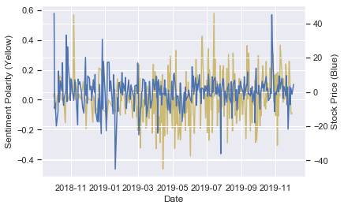

```python
run('tesla_news.csv', 'tsla_price-history.csv')
```

### Comparing Sentiment Polarity and Actual Stock Price

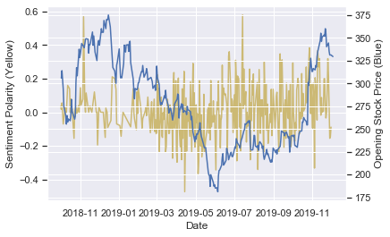

```python
def plotBoth(textDic , stockDF):
    textDF = pd.DataFrame.from_dict(textDic)
    textDF['date'] = pd.to_datetime(textDF['date']).dt.strftime('%Y:%B:%d')
    sns.set()
    sent = sns.lineplot(x = 'date', y = 'score', data = textDic, color = 'y', legend = 'brief')
    sent.set(xlabel = "Date", ylabel = "Sentiment Polarity (Yellow)")
    ax2 = plt.twinx()
    stock = sns.lineplot(x = 'date', y = 'Open', data = stockDF, color= 'b', ax = ax2, legend = 'full')
    stock.set(ylabel = "Opening Stock Price (Blue)")
run('tesla_news.csv', 'tsla_price-history.csv')
```

### Predicting with Sentence Sentiment Scores

Now, to take one step further, we explore the idea of predicting on stock price, given previous days' stock data and sentiment scores. This is done with SVMs. First, a new price column was assigned to the dataframe, and the price column was given the price of the previous date. We then merged the stock price dataframe and the sentiment score dictionary on date.

This procedure was selected because there weren't huge amounts of articles, due to the fact that we only had access to free data. This meant that one article could heavily influence the sentiment of that day, and largely impact the next day's stock price.

Different kernels and parameters of the SVM were run, and we decided that the SVM with RBF kernel performed the best. Also, instead of using only Sentiment Scores or only previous Day's stock prices, using both in the training process yielded the best predictions.

```python
def mergeDF(stockDF, dic):
    #Create a new column 'price' that contains stock price of current day
    newDF = pd.DataFrame.from_dict(dic)
    newDF['date'] = pd.to_datetime(newDF['date'])
    newDF['price'] = stockDF['Open']
    stockDF['date'] = stockDF['date'] - timedelta(1)

    bigDF = newDF.merge(stockDF, on = 'date')
    bigDF = bigDF.dropna(axis = 0)
    return bigDF

def svm(df, m):
    actual,predict,time = [],[],[]
    for i in range(0,df.shape[0]-m-1):
        svr = SVR(kernel = 'rbf', gamma = 'auto', C = 1e3)
        trainD = df.iloc[i:i+m,]
        testD = df.iloc[i+m:i+m+1,]
        X,y = np.asarray([trainD['score'],trainD['Last']]), trainD['price']
        svr.fit(X.T,y) #X.T
        testX = pd.DataFrame([testD['score'],testD['Last']])
        predicted = svr.predict(testX.T) #testX.T
        actual.extend(testD['price'].values)
        predict.extend(predicted)
        time.append(testD['date'].values[0])

    return actual, predict, time

def plotPrediction(actual, prediction, time):
    x = dict()
    x['Actual'], x['Predicted'], x['Date'] = actual,prediction,time
    df = pd.DataFrame.from_dict(x)
    sns.set()
    fig, ax = plt.subplots()
    sent = sns.lineplot(x = time, y = actual, color = 'b', ax = ax)
    hi = sns.lineplot(x = time, y = prediction, color = 'y', ax = ax)
    plt.xticks(rotation = 20)
    hi.set(ylabel = "Stock Price", xlabel = 'Time')
    plt.legend(labels=['Actual Price', 'Predicted Price'])
    return df

def main1(textPath, stockPath):
    textData = getData(textPath)
    stockData = getStock(stockPath)
    textDic = processText(textData)
    merged = mergeDF(stockData, textDic)
    a,p,t = svm(merged, 50)
    df = plotPrediction(a,p,t)
```

### Results of the Prediction

The plot below is the prediction on stock price, predicted by the sentiment score and the previous day's stock price. We can see that on some days, sentiment scores inversely affected stock price, again, due to the limited resources we had. However, the prediction was successful in capturing the general flow of the real stock prices. In the future, a more robust dataset from multiple sources could reduce possible bias, and we believe that the sentiment scores from a more objective dataset would lead us to a closer prediction of stock prices.

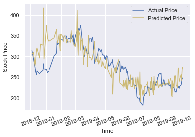

```python
textPath,stockPath = 'tesla_news.csv', 'tsla_price-history.csv'
textData = getData(textPath)
stockData = getStock(stockPath)
textDic = processText(textData)
tempStockT = stockData
tempDicT = textDic
merged = mergeDF(tempStockT, tempDicT)
a,p,t = svm(merged, 40)
sum_df2 = plotPrediction(a,p,t)
```